# Statistical_Methods

```python
import numpy as np
import pandas as pd
import matplotlib.pyplot as plt
import statsmodels.api as sm
import statsmodels.formula.api as smf
import seaborn as sns
import missingno as msno
import datetime as dt
from scipy.stats import shapiro, boxcox
from scipy.special import inv_boxcox
from scipy import stats
from scipy.stats import chi2
from scipy.stats import binom
from scipy.stats import mannwhitneyu
```

```python
from google.colab import drive
drive.mount('/content/drive')
```

```python
df = pd.read_csv("/content/drive/MyDrive/Statistical Method Project/Dataset/Pregnancy During the COVID-19 Pandemic - Pregnancy During the COVID-19 Pandemic (1).csv")
df.head()
```

|  | OSF_ID | Maternal_Age | Household_Income | Maternal_Education | Edinburgh_Postnatal_Depression_Scale | PROMIS_Anxiety | Gestational_Age_At_Birth | Delivery_Date(converted to month and year) | Birth_Length | Birth_Weight | Delivery_Mode | NICU_Stay | Language | Threaten_Life | Threaten_Baby_Danger | Threaten_Baby_Harm |
| --- | --- | --- | --- | --- | --- | --- | --- | --- | --- | --- | --- | --- | --- | --- | --- | --- |
| 0 | 1 | 38.3 | $200,000+ | Masters degree | 9.0 | 13.0 | 39.71 | Dec2020 | 49.20 | 3431.0 | Vaginally | No | English | 2.0 | 3.0 | 27.0 |
| 1 | 2 | 34.6 | $200,000+ | Undergraduate degree | 4.0 | 17.0 | NaN | NaN | NaN | NaN | NaN | NaN | English | 2.0 | 33.0 | 92.0 |
| 2 | 3 | 34.3 | $100,000 -$124,999 | Undergraduate degree | NaN | NaN | NaN | NaN | NaN | NaN | NaN | NaN | French | NaN | NaN | NaN |
| 3 | 4 | 28.8 | $100,000 -$124,999 | Masters degree | 9.0 | 20.0 | 38.57 | Dec2020 | 41.00 | 2534.0 | Vaginally | No | French | 53.0 | 67.0 | 54.0 |
| 4 | 5 | 36.5 | $40,000-$69,999 | Undergraduate degree | 14.0 | 20.0 | 39.86 | Oct2020 | 53.34 | 3714.0 | Caesarean-section (c-section) | No | English | 23.0 | 32.0 | 71.0 |

# **I. DATA PROCESSING**

## **1. Dataset Descriptions**

```python
df.info()
```

```
<class 'pandas.core.frame.DataFrame'>
RangeIndex: 10772 entries, 0 to 10771
Data columns (total 16 columns):
 #   Column                                      Non-Null Count  Dtype
---  ------                                      --------------  -----
 0   OSF_ID                                      10772 non-null  int64
 1   Maternal_Age                                10661 non-null  float64
 2   Household_Income                            10521 non-null  object
 3   Maternal_Education                          10595 non-null  object
 4   Edinburgh_Postnatal_Depression_Scale        9598 non-null   float64
 5   PROMIS_Anxiety                              9566 non-null   float64
 6   Gestational_Age_At_Birth                    6734 non-null   float64
 7   Delivery_Date(converted to month and year)  6733 non-null   object
 8   Birth_Length                                5480 non-null   float64
 9   Birth_Weight                                6078 non-null   float64
 10  Delivery_Mode                               5537 non-null   object
 11  NICU_Stay                                   5534 non-null   object
 12  Language                                    10772 non-null  object
 13  Threaten_Life                               9876 non-null   float64
 14  Threaten_Baby_Danger                        9868 non-null   float64
 15  Threaten_Baby_Harm                          9880 non-null   float64
dtypes: float64(9), int64(1), object(6)
memory usage: 1.3+ MB
```

```python
## Define the new names for the columns at index 4, 6 and 7
new_names = ['EPDS', 'GAbirth', 'Delivery_Date']

# Create a dictionary for renaming
rename_dict = {df.columns[4]: new_names[0], df.columns[6]: new_names[1], df.columns[7]: new_names[2]}

# Rename the columns
df.rename(columns=rename_dict, inplace=True)

# Save the modified dataset
df.to_csv('/content/drive/MyDrive/Statistical Method Project/Dataset/modified_df.csv', index=False)
```

```python
#checking after rename
df.head()
```

|  | OSF_ID | Maternal_Age | Household_Income | Maternal_Education | EPDS | PROMIS_Anxiety | GAbirth | Delivery_Date | Birth_Length | Birth_Weight | Delivery_Mode | NICU_Stay | Language | Threaten_Life | Threaten_Baby_Danger | Threaten_Baby_Harm |
| --- | --- | --- | --- | --- | --- | --- | --- | --- | --- | --- | --- | --- | --- | --- | --- | --- |
| 0 | 1 | 38.3 | $200,000+ | Masters degree | 9.0 | 13.0 | 39.71 | Dec2020 | 49.20 | 3431.0 | Vaginally | No | English | 2.0 | 3.0 | 27.0 |
| 1 | 2 | 34.6 | $200,000+ | Undergraduate degree | 4.0 | 17.0 | NaN | NaN | NaN | NaN | NaN | NaN | English | 2.0 | 33.0 | 92.0 |
| 2 | 3 | 34.3 | $100,000 -$124,999 | Undergraduate degree | NaN | NaN | NaN | NaN | NaN | NaN | NaN | NaN | French | NaN | NaN | NaN |
| 3 | 4 | 28.8 | $100,000 -$124,999 | Masters degree | 9.0 | 20.0 | 38.57 | Dec2020 | 41.00 | 2534.0 | Vaginally | No | French | 53.0 | 67.0 | 54.0 |
| 4 | 5 | 36.5 | $40,000-$69,999 | Undergraduate degree | 14.0 | 20.0 | 39.86 | Oct2020 | 53.34 | 3714.0 | Caesarean-section (c-section) | No | English | 23.0 | 32.0 | 71.0 |

## **2. Replace The Empty Value By NaN**

```python
df = df.replace(r'^\s+$', np.nan, regex=True)
df.head()
```

|  | OSF_ID | Maternal_Age | Household_Income | Maternal_Education | EPDS | PROMIS_Anxiety | GAbirth | Delivery_Date | Birth_Length | Birth_Weight | Delivery_Mode | NICU_Stay | Language | Threaten_Life | Threaten_Baby_Danger | Threaten_Baby_Harm |
| --- | --- | --- | --- | --- | --- | --- | --- | --- | --- | --- | --- | --- | --- | --- | --- | --- |
| 0 | 1 | 38.3 | $200,000+ | Masters degree | 9.0 | 13.0 | 39.71 | Dec2020 | 49.20 | 3431.0 | Vaginally | No | English | 2.0 | 3.0 | 27.0 |
| 1 | 2 | 34.6 | $200,000+ | Undergraduate degree | 4.0 | 17.0 | NaN | NaN | NaN | NaN | NaN | NaN | English | 2.0 | 33.0 | 92.0 |
| 2 | 3 | 34.3 | $100,000 -$124,999 | Undergraduate degree | NaN | NaN | NaN | NaN | NaN | NaN | NaN | NaN | French | NaN | NaN | NaN |
| 3 | 4 | 28.8 | $100,000 -$124,999 | Masters degree | 9.0 | 20.0 | 38.57 | Dec2020 | 41.00 | 2534.0 | Vaginally | No | French | 53.0 | 67.0 | 54.0 |
| 4 | 5 | 36.5 | $40,000-$69,999 | Undergraduate degree | 14.0 | 20.0 | 39.86 | Oct2020 | 53.34 | 3714.0 | Caesarean-section (c-section) | No | English | 23.0 | 32.0 | 71.0 |

## **3. Checking the Missing Values**

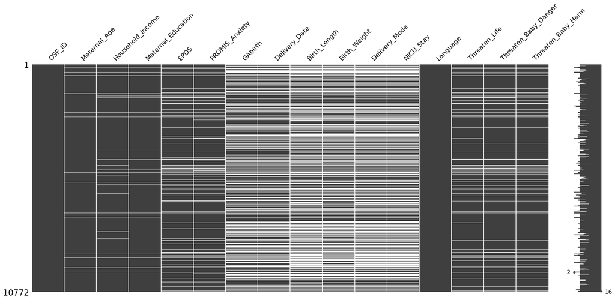

```python
msno.matrix(df);
```

```python
mask = df.isnull()
total = mask.sum()
percent = 100*mask.mean()

missing_data = pd.concat([total, percent], axis=1,join='outer',
               keys=['count_missing', 'perc_missing'])
missing_data.sort_values(by='perc_missing', ascending=False, inplace=True)

missing_data[missing_data.count_missing > 0]
```

|  | count_missing | perc_missing |
| --- | --- | --- |
| Birth_Length | 5292 | 49.127367 |
| NICU_Stay | 5238 | 48.626068 |
| Delivery_Mode | 5235 | 48.598218 |
| Birth_Weight | 4694 | 43.575938 |
| Delivery_Date | 4039 | 37.495358 |
| GAbirth | 4038 | 37.486075 |
| PROMIS_Anxiety | 1206 | 11.195693 |
| EPDS | 1174 | 10.898626 |
| Threaten_Baby_Danger | 904 | 8.392128 |
| Threaten_Life | 896 | 8.317861 |
| Threaten_Baby_Harm | 892 | 8.280728 |
| Household_Income | 251 | 2.330115 |
| Maternal_Education | 177 | 1.643149 |
| Maternal_Age | 111 | 1.030449 |

```python
df.nunique()
```

```
OSF_ID                  10772
Maternal_Age              279
Household_Income            9
Maternal_Education          6
EPDS                       31
PROMIS_Anxiety             29
GAbirth                    97
Delivery_Date              29
Birth_Length              172
Birth_Weight              706
Delivery_Mode               2
NICU_Stay                   2
Language                    2
Threaten_Life             101
Threaten_Baby_Danger      101
Threaten_Baby_Harm        101
dtype: int64
```

```python
df = df.drop(['Birth_Length', 'NICU_Stay', 'Delivery_Mode', 'Birth_Weight', 'Delivery_Date', 'GAbirth', 'Language'], axis=1)
df.columns
```

```
Index(['OSF_ID', 'Maternal_Age', 'Household_Income', 'Maternal_Education',
       'EPDS', 'PROMIS_Anxiety', 'Threaten_Life', 'Threaten_Baby_Danger',
       'Threaten_Baby_Harm'],
      dtype='object')
```

```python
df
```

|  | OSF_ID | Maternal_Age | Household_Income | Maternal_Education | EPDS | PROMIS_Anxiety | Threaten_Life | Threaten_Baby_Danger | Threaten_Baby_Harm |
| --- | --- | --- | --- | --- | --- | --- | --- | --- | --- |
| 0 | 1 | 38.3 | $200,000+ | Masters degree | 9.0 | 13.0 | 2.0 | 3.0 | 27.0 |
| 1 | 2 | 34.6 | $200,000+ | Undergraduate degree | 4.0 | 17.0 | 2.0 | 33.0 | 92.0 |
| 2 | 3 | 34.3 | $100,000 -$124,999 | Undergraduate degree | NaN | NaN | NaN | NaN | NaN |
| 3 | 4 | 28.8 | $100,000 -$124,999 | Masters degree | 9.0 | 20.0 | 53.0 | 67.0 | 54.0 |
| 4 | 5 | 36.5 | $40,000-$69,999 | Undergraduate degree | 14.0 | 20.0 | 23.0 | 32.0 | 71.0 |
| ... | ... | ... | ... | ... | ... | ... | ... | ... | ... |
| 10767 | 10768 | 38.3 | $100,000 -$124,999 | Undergraduate degree | 10.0 | 18.0 | 54.0 | 62.0 | 74.0 |
| 10768 | 10769 | 29.9 | $125,000- $149,999 | Undergraduate degree | NaN | NaN | NaN | NaN | NaN |
| 10769 | 10770 | 27.7 | $20,000- $39,999 | College/trade school | 4.0 | 15.0 | 21.0 | 93.0 | 76.0 |
| 10770 | 10771 | 23.0 | $20,000- $39,999 | College/trade school | 12.0 | 19.0 | 65.0 | 94.0 | 94.0 |
| 10771 | 10772 | 34.6 | $70,000-$99,999 | Masters degree | 18.0 | 30.0 | 84.0 | 73.0 | 94.0 |

10772 rows × 9 columns

```python
# Specify the file path where you want to save the new CSV file
output_file_path = '/content/drive/MyDrive/Statistical Method Project/Dataset/Preg Before Filling Missing Values.csv'

# Save the DataFrame to a CSV file
df.to_csv(output_file_path, index=False)

print(f"Cleaned data saved to {output_file_path}")
```

```
Cleaned data saved to /content/drive/MyDrive/Statistical Method Project/Dataset/Preg Before Filling Missing Values.csv
```

## **4.Dealing With The Missing Values**

### **a. Maternal_Education & Household_Income**

```python
df['Maternal_Education'] = pd.Categorical(df['Maternal_Education'], categories=['Less than high school diploma', 'High school diploma', 'College/trade school', 'Undergraduate degree', "Master's degree", 'Doctoral Degree'])
```

```python
df['Maternal_Education'] = df['Maternal_Education'].fillna(df['Maternal_Education'].mode()[0])
```

```python
df['Household_Income'] = df['Household_Income'].fillna(df['Household_Income'].mode()[0])
```

### **b. Maternal_Age**

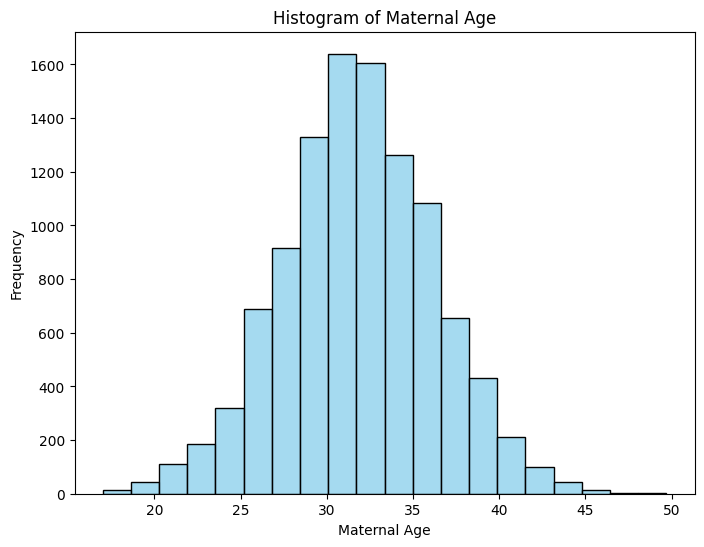

```python
import matplotlib.pyplot as plt
import seaborn as sns

# Plot a histogram
plt.figure(figsize=(8, 6))
sns.histplot(df['Maternal_Age'], kde=False, bins=20, color='skyblue')
plt.title('Histogram of Maternal Age')
plt.xlabel('Maternal Age')
plt.ylabel('Frequency')
plt.show()
```

The data is normally distributed, using the mean might be appropriate as it preserves the overall central tendency of the data.

```python
mean_age = df['Maternal_Age'].mean()
df['Maternal_Age'] = df['Maternal_Age'].fillna(mean_age)
```

```python
df['Maternal_Age'] = df['Maternal_Age'].round().astype(int)
```

### **c. EPDS & PROMIS_Anxiety**

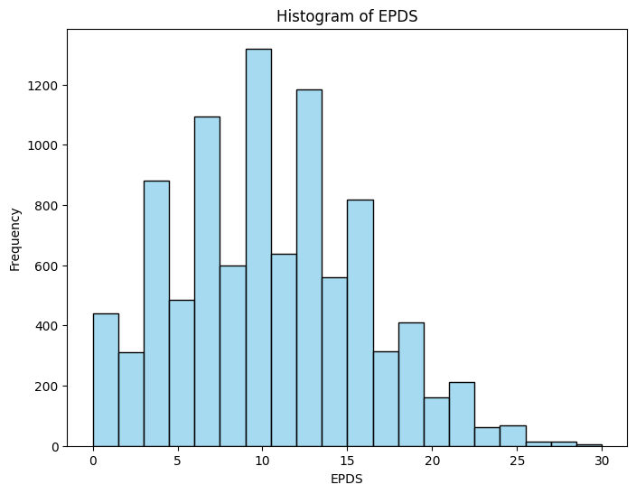

```python
plt.figure(figsize=(8, 6))
sns.histplot(df['EPDS'], kde=False, bins=20, color='skyblue')
plt.title('Histogram of EPDS')
plt.xlabel('EPDS')
plt.ylabel('Frequency')
plt.show()
```

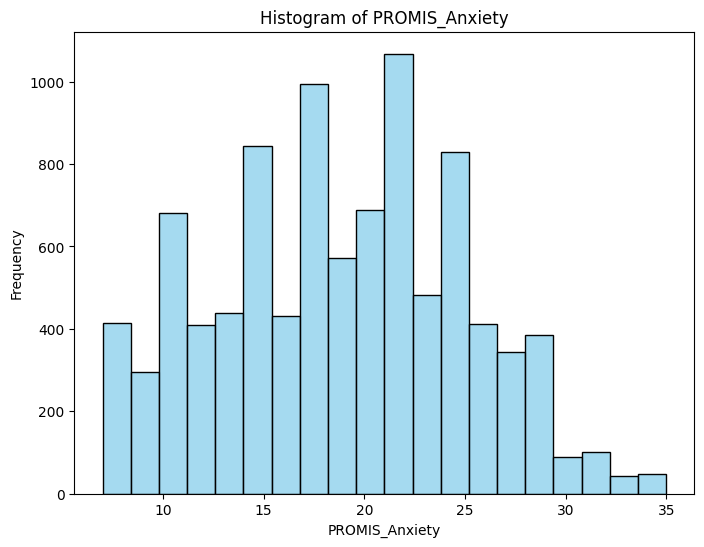

```python
plt.figure(figsize=(8, 6))
sns.histplot(df['PROMIS_Anxiety'], kde=False, bins=20, color='skyblue')
plt.title('Histogram of PROMIS_Anxiety')
plt.xlabel('PROMIS_Anxiety')
plt.ylabel('Frequency')
plt.show()
```

```python
# Interpolating specific columns
df[['EPDS', 'PROMIS_Anxiety']] = df[['EPDS', 'PROMIS_Anxiety']].interpolate()
df
```

|  | OSF_ID | Maternal_Age | Household_Income | Maternal_Education | EPDS | PROMIS_Anxiety | Threaten_Life | Threaten_Baby_Danger | Threaten_Baby_Harm |
| --- | --- | --- | --- | --- | --- | --- | --- | --- | --- |
| 0 | 1 | 38 | $200,000+ | Undergraduate degree | 9.0 | 13.0 | 2.0 | 3.0 | 27.0 |
| 1 | 2 | 35 | $200,000+ | Undergraduate degree | 4.0 | 17.0 | 2.0 | 33.0 | 92.0 |
| 2 | 3 | 34 | $100,000 -$124,999 | Undergraduate degree | 6.5 | 18.5 | NaN | NaN | NaN |
| 3 | 4 | 29 | $100,000 -$124,999 | Undergraduate degree | 9.0 | 20.0 | 53.0 | 67.0 | 54.0 |
| 4 | 5 | 36 | $40,000-$69,999 | Undergraduate degree | 14.0 | 20.0 | 23.0 | 32.0 | 71.0 |
| ... | ... | ... | ... | ... | ... | ... | ... | ... | ... |
| 10767 | 10768 | 38 | $100,000 -$124,999 | Undergraduate degree | 10.0 | 18.0 | 54.0 | 62.0 | 74.0 |
| 10768 | 10769 | 30 | $125,000- $149,999 | Undergraduate degree | 7.0 | 16.5 | NaN | NaN | NaN |
| 10769 | 10770 | 28 | $20,000- $39,999 | College/trade school | 4.0 | 15.0 | 21.0 | 93.0 | 76.0 |
| 10770 | 10771 | 23 | $20,000- $39,999 | College/trade school | 12.0 | 19.0 | 65.0 | 94.0 | 94.0 |
| 10771 | 10772 | 35 | $70,000-$99,999 | Undergraduate degree | 18.0 | 30.0 | 84.0 | 73.0 | 94.0 |

10772 rows × 9 columns

### **d. Other Variables**

```python
#Threaten_Life, Threaten_Baby_Danger, Threaten_Baby_Harm
columns_to_fill = ['Threaten_Life', 'Threaten_Baby_Danger', 'Threaten_Baby_Harm']
df[columns_to_fill] = df[columns_to_fill].fillna(0)
```

## **5. Fixing The Datatype**

```python
df.dtypes
```

```
OSF_ID                     int64
Maternal_Age               int64
Household_Income          object
Maternal_Education      category
EPDS                     float64
PROMIS_Anxiety           float64
Threaten_Life            float64
Threaten_Baby_Danger     float64
Threaten_Baby_Harm       float64
dtype: object
```

```python
df['EPDS'] = df['EPDS'].astype(int)
df['PROMIS_Anxiety'] = df['PROMIS_Anxiety'].astype(int)
```

```python
df.dtypes
```

```
OSF_ID                     int64
Maternal_Age               int64
Household_Income          object
Maternal_Education      category
EPDS                       int64
PROMIS_Anxiety             int64
Threaten_Life            float64
Threaten_Baby_Danger     float64
Threaten_Baby_Harm       float64
dtype: object
```

```python
df.isna().sum()
```

```
OSF_ID                  0
Maternal_Age            0
Household_Income        0
Maternal_Education      0
EPDS                    0
PROMIS_Anxiety          0
Threaten_Life           0
Threaten_Baby_Danger    0
Threaten_Baby_Harm      0
dtype: int64
```

```python
clean_df = df
```

```python
clean_df.head()
```

|  | OSF_ID | Maternal_Age | Household_Income | Maternal_Education | EPDS | PROMIS_Anxiety | Threaten_Life | Threaten_Baby_Danger | Threaten_Baby_Harm |
| --- | --- | --- | --- | --- | --- | --- | --- | --- | --- |
| 0 | 1 | 38 | $200,000+ | Undergraduate degree | 9 | 13 | 2.0 | 3.0 | 27.0 |
| 1 | 2 | 35 | $200,000+ | Undergraduate degree | 4 | 17 | 2.0 | 33.0 | 92.0 |
| 2 | 3 | 34 | $100,000 -$124,999 | Undergraduate degree | 6 | 18 | 0.0 | 0.0 | 0.0 |
| 3 | 4 | 29 | $100,000 -$124,999 | Undergraduate degree | 9 | 20 | 53.0 | 67.0 | 54.0 |
| 4 | 5 | 36 | $40,000-$69,999 | Undergraduate degree | 14 | 20 | 23.0 | 32.0 | 71.0 |

## **6. Finding Outliers**

```python
# Calculate IQR for EPDS
Q1_EPDS = df['EPDS'].quantile(0.25)
Q3_EPDS = df['EPDS'].quantile(0.75)
IQR_EPDS = Q3_EPDS - Q1_EPDS

# Calculate lower and upper bounds for EPDS outliers
lower_bound_EPDS = Q1_EPDS - 1.5 * IQR_EPDS
upper_bound_EPDS = Q3_EPDS + 1.5 * IQR_EPDS

# Calculate IQR for PROMIS_Anxiety
Q1_PROMIS_Anxiety = df['PROMIS_Anxiety'].quantile(0.25)
Q3_PROMIS_Anxiety = df['PROMIS_Anxiety'].quantile(0.75)
IQR_PROMIS_Anxiety = Q3_PROMIS_Anxiety - Q1_PROMIS_Anxiety

# Calculate lower and upper bounds for PROMIS_Anxiety outliers
lower_bound_PROMIS_Anxiety = Q1_PROMIS_Anxiety - 1.5 * IQR_PROMIS_Anxiety
upper_bound_PROMIS_Anxiety = Q3_PROMIS_Anxiety + 1.5 * IQR_PROMIS_Anxiety

# Display results
print("EPDS IQR:", IQR_EPDS)
print("EPDS Lower Bound for Outliers:", lower_bound_EPDS)
print("EPDS Upper Bound for Outliers:", upper_bound_EPDS)

print("")

print("PROMIS_Anxiety IQR:", IQR_PROMIS_Anxiety)
print("PROMIS_Anxiety Lower Bound for Outliers:", lower_bound_PROMIS_Anxiety)
print("PROMIS_Anxiety Upper Bound for Outliers:", upper_bound_PROMIS_Anxiety)

# Identify outliers
EPDS_outliers = df[(df['EPDS'] < lower_bound_EPDS) | (df['EPDS'] > upper_bound_EPDS)]
PROMIS_Anxiety_outliers = df[(df['PROMIS_Anxiety'] < lower_bound_PROMIS_Anxiety) | (df['PROMIS_Anxiety'] > upper_bound_PROMIS_Anxiety)]

print("")
print("EPDS Outliers:\n", EPDS_outliers)
print("")
print("PROMIS_Anxiety Outliers:\n", PROMIS_Anxiety_outliers)
```

```
EPDS IQR: 8.0
EPDS Lower Bound for Outliers: -6.0
EPDS Upper Bound for Outliers: 26.0

PROMIS_Anxiety IQR: 9.0
PROMIS_Anxiety Lower Bound for Outliers: 0.5
PROMIS_Anxiety Upper Bound for Outliers: 36.5

EPDS Outliers:
       OSF_ID  Maternal_Age    Household_Income    Maternal_Education  EPDS  \
33        34            20  Less than $20, 000  College/trade school    27
184      185            32     $40,000-$69,999  College/trade school    28
780      781            34    $20,000- $39,999  Undergraduate degree    29
880      881            22  Less than $20, 000   High school diploma    27
1443    1444            30     $70,000-$99,999  College/trade school    27
```

[output cut: 42 more lines]

```python
# Calculate number and percentage of outliers
num_EPDS_outliers = len(EPDS_outliers)
num_PROMIS_Anxiety_outliers = len(PROMIS_Anxiety_outliers)

percent_EPDS_outliers = (num_EPDS_outliers / len(df)) * 100
percent_PROMIS_Anxiety_outliers = (num_PROMIS_Anxiety_outliers / len(df)) * 100

# Display number and percentage of outliers
print("Number of EPDS Outliers:", num_EPDS_outliers)
print("Percentage of EPDS Outliers: {:.2f}%".format(percent_EPDS_outliers))
print("")
print("Number of PROMIS Anxiety Outliers:", num_PROMIS_Anxiety_outliers)
print("Percentage of PROMIS Anxiety Outliers: {:.2f}%".format(percent_PROMIS_Anxiety_outliers))
```

```
Number of EPDS Outliers: 20
Percentage of EPDS Outliers: 0.19%

Number of PROMIS Anxiety Outliers: 0
Percentage of PROMIS Anxiety Outliers: 0.00%
```

## **7. Saving Data After Processing**

```python
# Specify the file path where you want to save the new CSV file
output_file_path = '/content/drive/MyDrive/Statistical Method Project/Dataset/preg_finalupdate.csv'

# Save the DataFrame to a CSV file
df.to_csv(output_file_path, index=False)

print(f"Cleaned data saved to {output_file_path}")
```

```
Cleaned data saved to /content/drive/MyDrive/Statistical Method Project/Dataset/preg_finalupdate.csv
```

# **II. DESCRIPTIVE STATISTICS**

```python
df = pd.read_csv('/content/drive/MyDrive/Statistical Method Project/Dataset/preg_finalupdate.csv')
df.head()
```

|  | OSF_ID | Maternal_Age | Household_Income | Maternal_Education | EPDS | PROMIS_Anxiety | Threaten_Life | Threaten_Baby_Danger | Threaten_Baby_Harm |
| --- | --- | --- | --- | --- | --- | --- | --- | --- | --- |
| 0 | 1 | 38 | $200,000+ | Undergraduate degree | 9 | 13 | 2.0 | 3.0 | 27.0 |
| 1 | 2 | 35 | $200,000+ | Undergraduate degree | 4 | 17 | 2.0 | 33.0 | 92.0 |
| 2 | 3 | 34 | $100,000 -$124,999 | Undergraduate degree | 6 | 18 | 0.0 | 0.0 | 0.0 |
| 3 | 4 | 29 | $100,000 -$124,999 | Undergraduate degree | 9 | 20 | 53.0 | 67.0 | 54.0 |
| 4 | 5 | 36 | $40,000-$69,999 | Undergraduate degree | 14 | 20 | 23.0 | 32.0 | 71.0 |

## **1. Edinburgh Postnatal Depression Scale (EPDS)**

### **a. Frequency Analysis**

```python
EPDS_groups = [
    ("0-13", df["EPDS"].between(0, 13)),
    ("13-above", df["EPDS"] > 13)
]

for group_name, condition in EPDS_groups:
    count = df[condition].shape[0]
    print(f"Frequency of {group_name}: {count}")
```

```
Frequency of 0-13: 7918
Frequency of 13-above: 2854
```

### **b. Mean, Median, Mode**

```
Mean: 10.155774229483846
Mode: 9
Median: 10.0
```

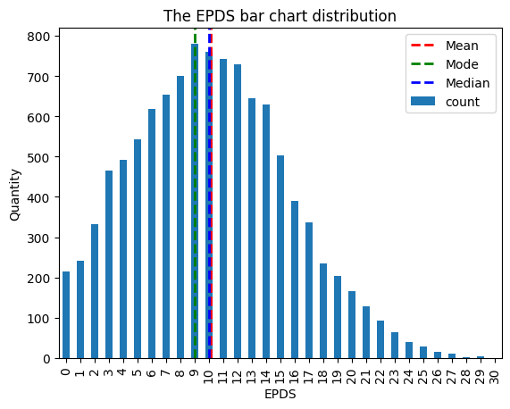

```python
mean_EPDS = df['EPDS'].mean()
mode_EPDS = df['EPDS'].mode()[0]
median_EPDS = df['EPDS'].median()

# Print the results
print(f"Mean: {mean_EPDS}")
print(f"Mode: {mode_EPDS}")
print(f"Median: {median_EPDS}")

# Create a bar chart of EPDS distribution
epds_counts = df['EPDS'].value_counts().sort_index()

epds_counts.plot(kind='bar')

plt.title("The EPDS bar chart distribution")
plt.xlabel("EPDS")
plt.ylabel("Quantity")

plt.axvline(mean_EPDS, color='r', linestyle='dashed', linewidth=2, label='Mean')
plt.axvline(mode_EPDS, color='g', linestyle='dashed', linewidth=2, label='Mode')
plt.axvline(median_EPDS, color='b', linestyle='dashed', linewidth=2, label='Median')
plt.legend()

# Display the chart
plt.show()
```

### **c. Five-summary numbers and Box plot**

```python
print(df['EPDS'].describe())
```

```
count    10772.000000
mean        10.155774
std          5.369242
min          0.000000
25%          6.000000
50%         10.000000
75%         14.000000
max         30.000000
Name: EPDS, dtype: float64
```

```
Axes(0.125,0.11;0.775x0.77)
```

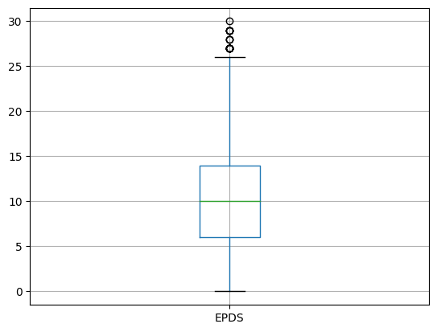

```python
print(df.boxplot(column='EPDS', vert=True))
```

## **2. PROMIS Anxiety**

### **a. Frequency Analysis**

```python
PROMIS_Anxiety_levels = [
    ("7-15", df["PROMIS_Anxiety"].between(7, 15)),
    ("16-19", df["PROMIS_Anxiety"].between(16, 19)),
    ("20-27", df["PROMIS_Anxiety"].between(20, 27)),
    ( "28-35", df["PROMIS_Anxiety"].between(28, 35))
]

for group_name, condition in PROMIS_Anxiety_levels:
    count = df[condition].shape[0]
    print(f"Frequency of {group_name}: {count}")
```

```
Frequency of 7-15: 3419
Frequency of 16-19: 2402
Frequency of 20-27: 4266
Frequency of 28-35: 685
```

### **b. Mean, Median, Mode**

```
Mean: 18.618640920906053
Mode: 20
Median: 19.0
```

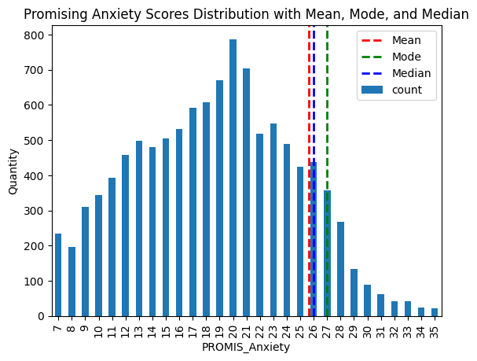

```python
mean_PROMIS_Anxiety = df['PROMIS_Anxiety'].mean()
mode_PROMIS_Anxiety = df['PROMIS_Anxiety'].mode()[0]
median_PROMIS_Anxiety = df['PROMIS_Anxiety'].median()

# Print the results
print(f"Mean: {mean_PROMIS_Anxiety}")
print(f"Mode: {mode_PROMIS_Anxiety}")
print(f"Median: {median_PROMIS_Anxiety}")

# Create a bar chart of PROMIS Anxiety distribution
promis_anxiety_counts = df['PROMIS_Anxiety'].value_counts().sort_index()

promis_anxiety_counts.plot(kind='bar')

plt.title("Promising Anxiety Scores Distribution with Mean, Mode, and Median")
plt.xlabel("PROMIS_Anxiety")
plt.ylabel("Quantity")

plt.axvline(mean_PROMIS_Anxiety, color='r', linestyle='dashed', linewidth=2, label='Mean')
plt.axvline(mode_PROMIS_Anxiety, color='g', linestyle='dashed', linewidth=2, label='Mode')
plt.axvline(median_PROMIS_Anxiety, color='b', linestyle='dashed', linewidth=2, label='Median')
plt.legend()

# Display the chart
plt.show()
```

### **c. Five-summary numbers and Box plot**

```python
print(df['PROMIS_Anxiety'].describe())
```

```
count    10772.000000
mean        18.618641
std          5.927888
min          7.000000
25%         14.000000
50%         19.000000
75%         23.000000
max         35.000000
Name: PROMIS_Anxiety, dtype: float64
```

```
Axes(0.125,0.11;0.775x0.77)
```

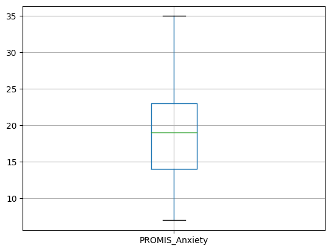

```python
print(df.boxplot(column='PROMIS_Anxiety', vert=True))
```

## **3. Maternal Education**

### **a. Frequency Analysis**

```python
education_counts = df['Maternal_Education'].value_counts()
print(education_counts)
```

```
Maternal_Education
Undergraduate degree             6183
College/trade school             2760
High school diploma               901
Doctoral Degree                   786
Less than high school diploma     142
Name: count, dtype: int64
```

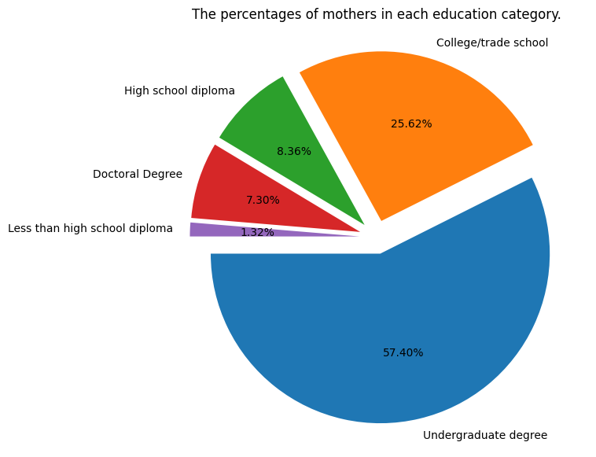

```python
plt.figure(figsize=(10, 7))
plt.pie(education_counts, labels=education_counts.index, autopct='%1.2f%%', startangle = 180, explode = [0.1, 0.1, 0.1, 0.1,0.1])
plt.title('The percentages of mothers in each education category.')
plt.show()
```

### **b. Mean EPDS For Each Group Of Maternal Education**

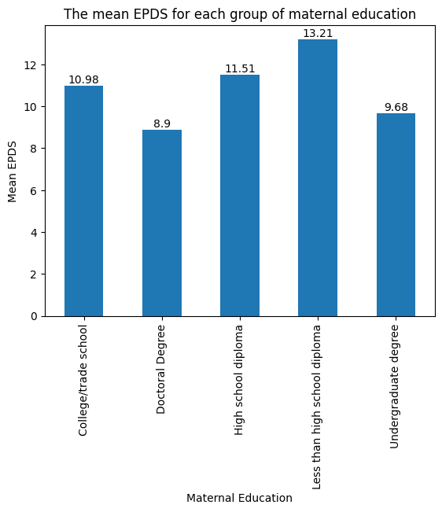

```python
df_grouped_EPDS = df.groupby('Maternal_Education')['EPDS'].mean()
chart_EPDS = df_grouped_EPDS.plot(kind='bar')

for index, value in enumerate(df_grouped_EPDS):
    chart_EPDS.text(index, value, str(round(value, 2)), ha='center', va='bottom')

plt.title("The mean EPDS for each group of maternal education")
plt.xlabel('Maternal Education')
plt.ylabel('Mean EPDS')
plt.show()
```

### **c. Mean Anxiety For Each Group Of Maternal Education**

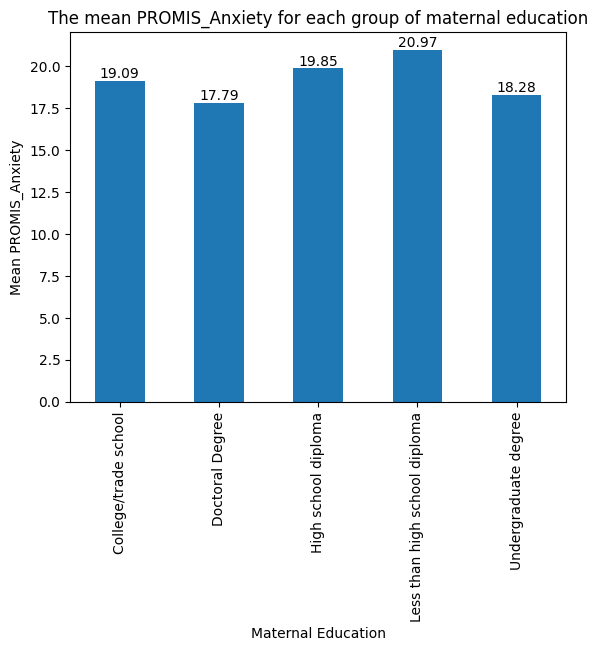

```python
df_grouped_PROMIS_Anxiety = df.groupby('Maternal_Education')['PROMIS_Anxiety'].mean()
chart_PROMIS_Anxiety = df_grouped_PROMIS_Anxiety.plot(kind='bar')

for index, value in enumerate(df_grouped_PROMIS_Anxiety):
    chart_PROMIS_Anxiety.text(index, value, str(round(value, 2)), ha='center', va='bottom')

plt.title("The mean PROMIS_Anxiety for each group of maternal education")
plt.xlabel('Maternal Education')
plt.ylabel('Mean PROMIS_Anxiety')
plt.show()
```

# **III. NORMALITY CHECKING**

## **1. Check Normality For EPDS**

### **a. Graphical Check**

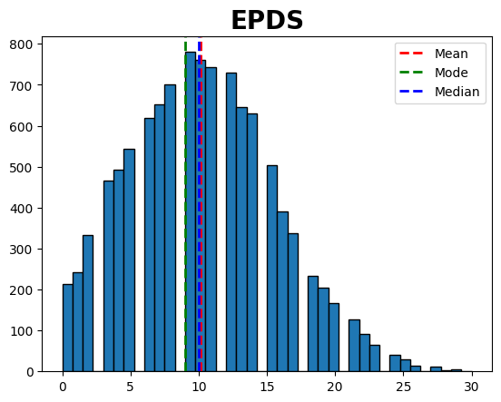

```python
mean_EPDS = df['EPDS'].mean()
mode_EPDS = df['EPDS'].mode()[0]
median_EPDS = df['EPDS'].median()

plt.hist(df['EPDS'], edgecolor='black', bins=40)
plt.title('EPDS', weight='bold', size=20)
plt.axvline(mean_EPDS, color='r', linestyle='dashed', linewidth=2, label='Mean')
plt.axvline(mode_EPDS, color='g', linestyle='dashed', linewidth=2, label='Mode')
plt.axvline(median_EPDS, color='b', linestyle='dashed', linewidth=2, label='Median')
plt.legend()
plt.show()
```

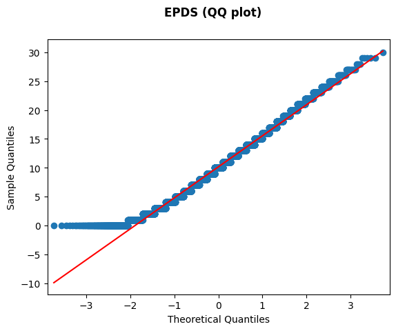

```python
EPDS_qqplot = sm.qqplot(df['EPDS'], line='s')
EPDS_qqplot.suptitle('EPDS (QQ plot)', weight='bold')
plt.show()
```

### **b. Statistical Check (D’Agostino K^2 Test)**

```python
k2, p = stats.normaltest(df['EPDS'])

if p < 0.05:
    print("The null hypothesis can be rejected. The data does not seem to be normally distributed.")
else:
    print("The null hypothesis cannot be rejected. The data seems to be normally distributed.")
print("P_Value=",p)
```

```
The null hypothesis can be rejected. The data does not seem to be normally distributed.
P_Value= 6.779067050728034e-45
```

## **2. Check Normality For PROMIS Anxiety**

### **a. Graphical Check**

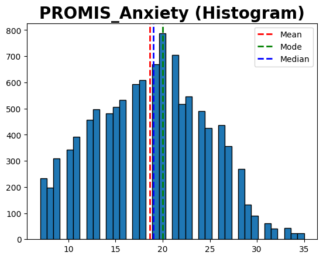

```python
mean_PROMIS_Anxiety = df['PROMIS_Anxiety'].mean()
mode_PROMIS_Anxiety= df['PROMIS_Anxiety'].mode()[0]
median_PROMIS_Anxiety=df['PROMIS_Anxiety'].median()

plt.hist(df['PROMIS_Anxiety'], edgecolor='black', bins=40)
plt.title('PROMIS_Anxiety (Histogram)', weight='bold', size=20)
plt.axvline(mean_PROMIS_Anxiety, color='r', linestyle='dashed', linewidth=2, label='Mean')
plt.axvline(mode_PROMIS_Anxiety, color='g', linestyle='dashed', linewidth=2, label='Mode')
plt.axvline(median_PROMIS_Anxiety, color='b', linestyle='dashed', linewidth=2, label='Median')
plt.legend()
plt.show()
```

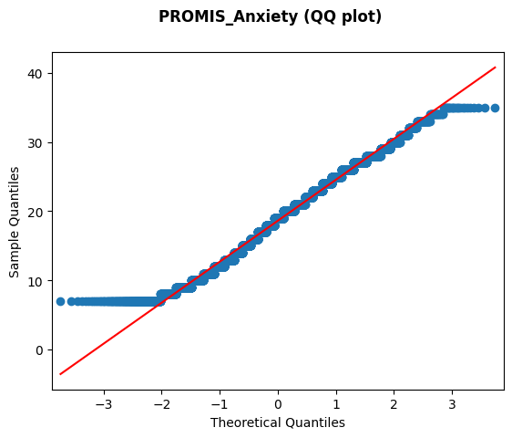

```python
PROMIS_Anxiety_qqplot = sm.qqplot(df['PROMIS_Anxiety'], line='s')
PROMIS_Anxiety_qqplot.suptitle('PROMIS_Anxiety (QQ plot)', weight='bold')
plt.show()
```

### **b. Statistical Check (D’Agostino K^2 Test)**

```python
k2, p = stats.normaltest(df['PROMIS_Anxiety'])

if p < 0.05:
    print("The null hypothesis can be rejected. The data does not seem to be normally distributed.")
else:
    print("The null hypothesis cannot be rejected. The data seems to be normally distributed.")
print("P_Value=",p)
```

```
The null hypothesis can be rejected. The data does not seem to be normally distributed.
P_Value= 7.860400674094453e-88
```

## **2. Yeojohnson Transformation**

### **a. Yeojohnson EPDS**

```python
yeojohnson_EPDS, lamda_EPDS =stats.yeojohnson(df['EPDS'])
```

```python
df['yeojohnson_EPDS']= yeojohnson_EPDS
```

```
Mean: 6.109285832883042
Mode: 5.747188139233468
Median: 6.243397881818789
```

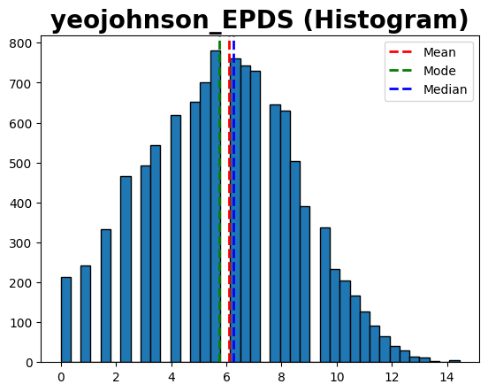

```python
mean_yeojohnson_EPDS = df['yeojohnson_EPDS'].mean()
mode_yeojohnson_EPDS = df['yeojohnson_EPDS'].mode()[0]
median_yeojohnson_EPDS = df['yeojohnson_EPDS'].median()

print("Mean:", mean_yeojohnson_EPDS)
print("Mode:", mode_yeojohnson_EPDS)
print("Median:", median_yeojohnson_EPDS)

plt.hist(df['yeojohnson_EPDS'], edgecolor='black', bins=40)
plt.title('yeojohnson_EPDS (Histogram)', weight='bold', size=20)
plt.axvline(mean_yeojohnson_EPDS, color='r', linestyle='dashed', linewidth=2, label='Mean')
plt.axvline(mode_yeojohnson_EPDS, color='g', linestyle='dashed', linewidth=2, label='Mode')
plt.axvline(median_yeojohnson_EPDS, color='b', linestyle='dashed', linewidth=2, label='Median')
plt.legend()
plt.show()
```

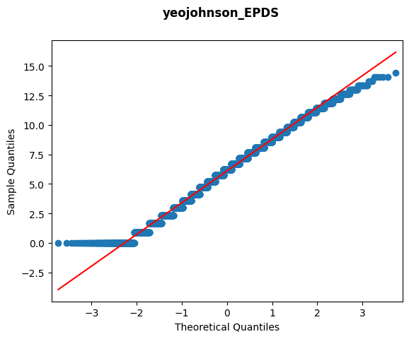

```python
yeojohnson_EPDS_qqplot = sm.qqplot(df['yeojohnson_EPDS'], line='s')
yeojohnson_EPDS_qqplot.suptitle('yeojohnson_EPDS', weight='bold')
plt.show()
```

```python
k2, p = stats.normaltest(df['yeojohnson_EPDS'])

if p < 0.05:
    print("The null hypothesis can be rejected. The data does not seem to be normally distributed.")
else:
    print("The null hypothesis cannot be rejected. The data seems to be normally distributed.")
print("P_Value=",p)
```

```
The null hypothesis can be rejected. The data does not seem to be normally distributed.
P_Value= 6.744442000065945e-24
```

### **b. Yeojohnson Anxiety**

```python
yeojohnson_PROMIS_Anxiety, lamda_PROMIS_Anxiety=stats.yeojohnson(df['PROMIS_Anxiety'])
```

```python
df['yeojohnson_PROMIS_Anxiety'] = yeojohnson_PROMIS_Anxiety
```

```
Mean: 12.71930953047842
Mode: 13.624198134036538
Median: 13.041188637670341
```

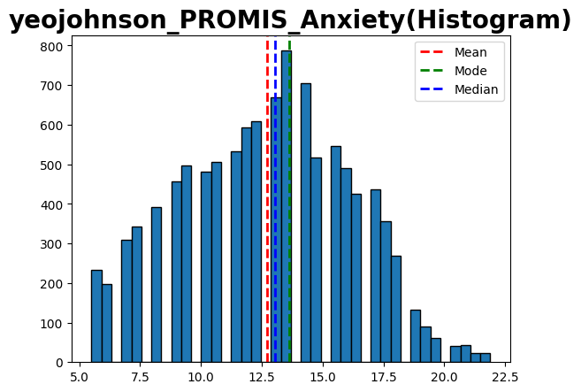

```python
mean_yeojohnson_PROMIS_Anxiety = df['yeojohnson_PROMIS_Anxiety'].mean()
mode_yeojohnson_PROMIS_Anxiety= df['yeojohnson_PROMIS_Anxiety'].mode()[0]
median_yeojohnson_PROMIS_Anxiety = df['yeojohnson_PROMIS_Anxiety'].median()

print("Mean:", mean_yeojohnson_PROMIS_Anxiety)
print("Mode:", mode_yeojohnson_PROMIS_Anxiety)
print("Median:", median_yeojohnson_PROMIS_Anxiety)

plt.hist(df['yeojohnson_PROMIS_Anxiety'], edgecolor='black', bins=40)
plt.title('yeojohnson_PROMIS_Anxiety(Histogram)', weight='bold', size=20)
plt.axvline(mean_yeojohnson_PROMIS_Anxiety, color='r', linestyle='dashed', linewidth=2, label='Mean')
plt.axvline(mode_yeojohnson_PROMIS_Anxiety, color='g', linestyle='dashed', linewidth=2, label='Mode')
plt.axvline(median_yeojohnson_PROMIS_Anxiety, color='b', linestyle='dashed', linewidth=2, label='Median')
plt.legend()
plt.show()
```

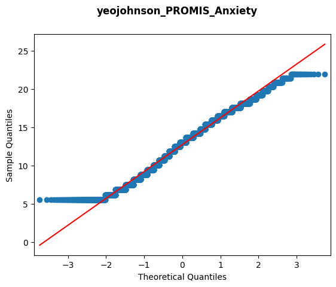

```python
yeojohnson_PROMIS_Anxiety_qqplot = sm.qqplot(df['yeojohnson_PROMIS_Anxiety'], line='s')
yeojohnson_PROMIS_Anxiety_qqplot.suptitle('yeojohnson_PROMIS_Anxiety', weight='bold')
plt.show()
```

```python
k2, p = stats.normaltest(df['yeojohnson_PROMIS_Anxiety'])

if p < 0.05:
    print("The null hypothesis can be rejected. The data does not seem to be normally distributed.")
else:
    print("The null hypothesis cannot be rejected. The data seems to be normally distributed.")
print("P_Value=",p)
```

```
The null hypothesis can be rejected. The data does not seem to be normally distributed.
P_Value= 5.944074179181394e-97
```

**Promis anxiety and EPDS still not be normal after transformation**

# **IV. REGRESSION ANALYSIS**

## **1. Least-Squares Regression Line**

```python
model = smf.ols('EPDS ~ PROMIS_Anxiety', data=df)
results = model.fit()
print(results.summary())
```

```
                            OLS Regression Results
==============================================================================
Dep. Variable:                   EPDS   R-squared:                       0.650
Model:                            OLS   Adj. R-squared:                  0.650
Method:                 Least Squares   F-statistic:                 2.003e+04
Date:                Mon, 17 Jun 2024   Prob (F-statistic):               0.00
Time:                        09:16:21   Log-Likelihood:                -27730.
No. Observations:               10772   AIC:                         5.546e+04
Df Residuals:                   10770   BIC:                         5.548e+04
Df Model:                           1
Covariance Type:            nonrobust
==================================================================================
                     coef    std err          t      P>|t|      [0.025      0.975]
----------------------------------------------------------------------------------
Intercept         -3.4437      0.101    -34.148      0.000      -3.641      -3.246
PROMIS_Anxiety     0.7304      0.005    141.523      0.000       0.720       0.741
==============================================================================
Omnibus:                      160.784   Durbin-Watson:                   1.788
Prob(Omnibus):                  0.000   Jarque-Bera (JB):              208.115
Skew:                           0.212   Prob(JB):                     6.43e-46
Kurtosis:                       3.532   Cond. No.                         64.6
==============================================================================

Notes:
[1] Standard Errors assume that the covariance matrix of the errors is correctly specified.
```

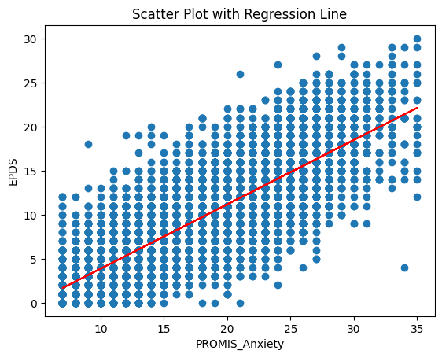

```python
X = df['PROMIS_Anxiety']
Y = df['EPDS']
X_mean = np.mean(X)
Y_mean = np.mean(Y)
cov= np.sum((X - X_mean)*(Y - Y_mean))
var = np.sum((X - X_mean)**2)
slope = cov/var
intercept = Y_mean - slope * X_mean

regression_line = slope * X + intercept

plt.scatter(df['PROMIS_Anxiety'], df['EPDS'])
plt.plot(X, regression_line, color='red')
plt.xlabel('PROMIS_Anxiety')
plt.ylabel('EPDS')
plt.title('Scatter Plot with Regression Line')
plt.show()
```

## **2. Four Key Assumptions of Linear Regression**

### **a. Linearity**

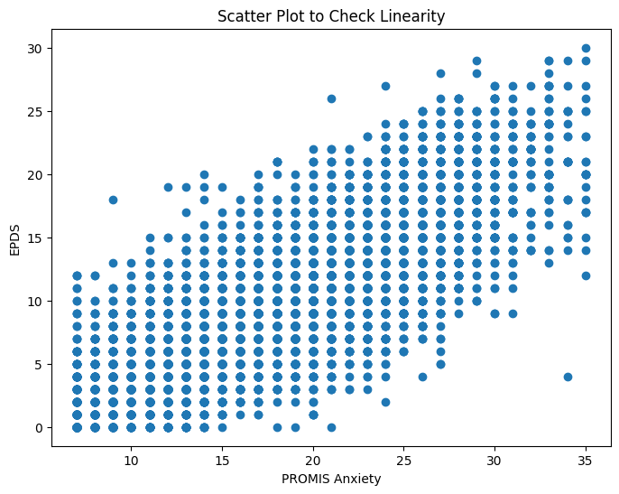

```python
x=df['PROMIS_Anxiety']
y=df['EPDS']
# Create the scatter plot
plt.figure(figsize=(8, 6))
plt.scatter(x, y)
plt.xlabel('PROMIS Anxiety')
plt.ylabel('EPDS')
plt.title('Scatter Plot to Check Linearity')
plt.show()
```

### **b. Independence**

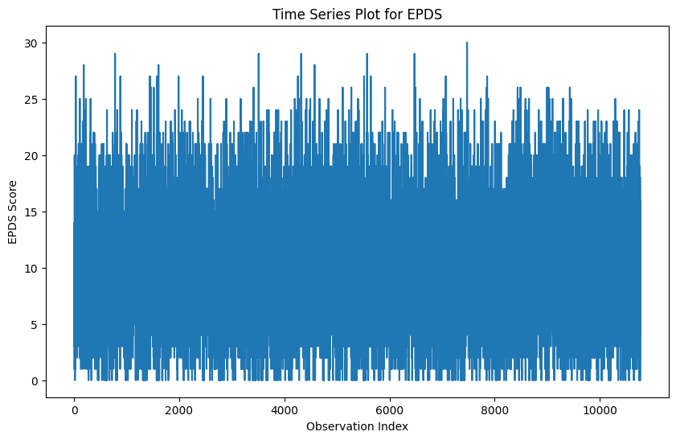

```python
plt.figure(figsize=(10, 6))
plt.plot(df['EPDS'])
plt.title('Time Series Plot for EPDS')
plt.xlabel('Observation Index')
plt.ylabel('EPDS Score')
plt.show()
```

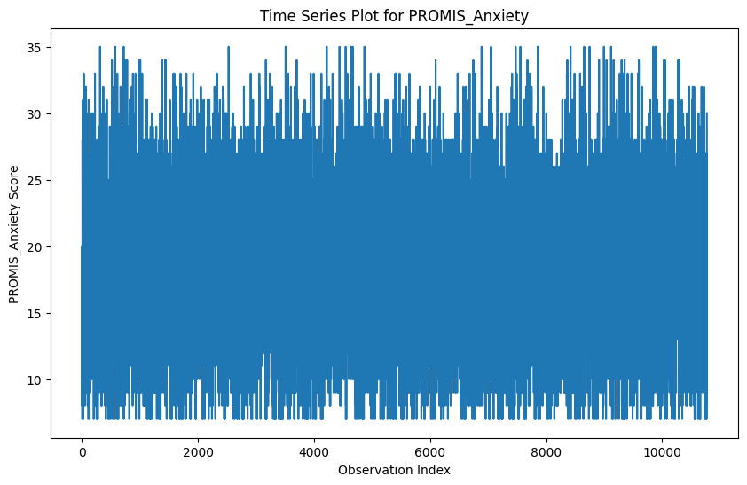

```python
plt.figure(figsize=(10, 6))
plt.plot(df['PROMIS_Anxiety'])
plt.title('Time Series Plot for PROMIS_Anxiety')
plt.xlabel('Observation Index')
plt.ylabel('PROMIS_Anxiety Score')
plt.show()
```

```python
model = sm.OLS(df['EPDS'], df['PROMIS_Anxiety']).fit()
durbin_watson = sm.stats.durbin_watson(model.resid)

print(f"Durbin-Watson statistic: {durbin_watson:.2f}")
```

```
Durbin-Watson statistic: 1.77
```

### **c. Homoscedasticity**

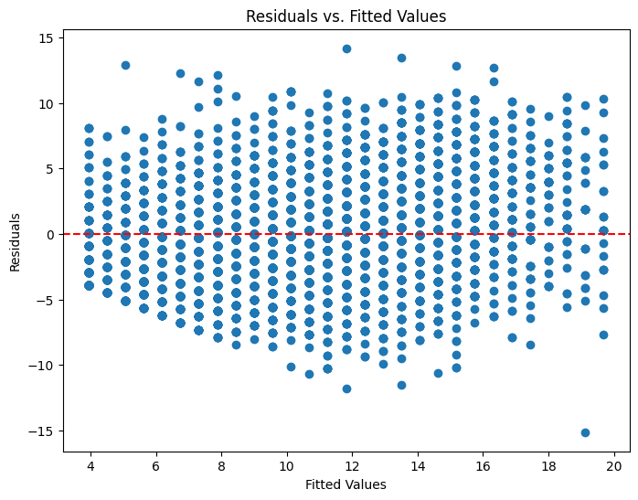

```python
model = sm.OLS(df['EPDS'], df['PROMIS_Anxiety']).fit()

residuals = model.resid
fitted_values = model.fittedvalues

plt.figure(figsize=(8, 6))
plt.scatter(fitted_values, residuals)
plt.xlabel('Fitted Values')
plt.ylabel('Residuals')
plt.title('Residuals vs. Fitted Values')
plt.axhline(y=0, color='red', linestyle='--')
plt.show()
```

### **d. Normality**

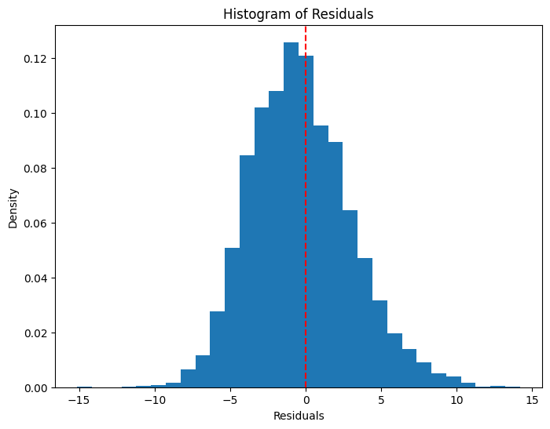

```python
model = sm.OLS(df['EPDS'], df['PROMIS_Anxiety']).fit()
residuals = model.resid

plt.figure(figsize=(8, 6))
plt.hist(residuals, bins=30, density=True)
plt.xlabel('Residuals')
plt.ylabel('Density')
plt.title('Histogram of Residuals')
plt.axvline(x=0, color='red', linestyle='--')
plt.show()
```

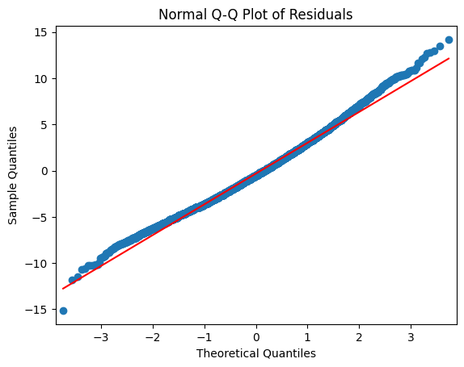

```python
model = sm.OLS(df['EPDS'], df['PROMIS_Anxiety']).fit()
residuals = model.resid

plt.figure(figsize=(8, 6))
sm.qqplot(residuals, line='s')
plt.xlabel('Theoretical Quantiles')
plt.ylabel('Sample Quantiles')
plt.title('Normal Q-Q Plot of Residuals')
plt.show()
```

# **V. CONFIDENCE INTERVAL (BOOTSTRAPPING)**

## **1. The confidence interval for population mean EPDS and PROMIS Anxiety scores**

```python
n_bootstrap = 1000

epds_means = []
anxiety_means = []

for _ in range(n_bootstrap):
    epds_boot = np.random.choice(df['EPDS'], size=len(df['EPDS']), replace=True)
    anxiety_boot = np.random.choice(df['PROMIS_Anxiety'], size=len(df['PROMIS_Anxiety']), replace=True)
    epds_means.append(np.mean(epds_boot))
    anxiety_means.append(np.mean(anxiety_boot))

epds_ci_low = np.percentile(epds_means, 2.5)
epds_ci_high = np.percentile(epds_means, 97.5)
print(f"Confidence interval for mean EPDS: ({epds_ci_low:.2f}, {epds_ci_high:.2f})")

anxiety_ci_low = np.percentile(anxiety_means, 2.5)
anxiety_ci_high = np.percentile(anxiety_means, 97.5)
print(f"Confidence interval for mean PROMIS_Anxiety: ({anxiety_ci_low:.2f}, {anxiety_ci_high:.2f})")
```

```
Confidence interval for mean EPDS: (10.06, 10.25)
Confidence interval for mean PROMIS_Anxiety: (18.51, 18.74)
```

## **2. The confidence interval for population variance and standard deviation EPDS and PROMIS Anxiety scores**

```python
epds_vars = []
anxiety_vars = []

for _ in range(n_bootstrap):
    epds_boot = np.random.choice(df['EPDS'], size=len(df['EPDS']), replace=True)
    anxiety_boot = np.random.choice(df['PROMIS_Anxiety'], size=len(df['PROMIS_Anxiety']), replace=True)
    epds_vars.append(np.var(epds_boot))
    anxiety_vars.append(np.var(anxiety_boot))

epds_var_ci_low = np.percentile(epds_vars, 2.5)
epds_var_ci_high = np.percentile(epds_vars, 97.5)
epds_sd_ci_low = np.sqrt(epds_var_ci_low)
epds_sd_ci_high = np.sqrt(epds_var_ci_high)
print(f"Confidence interval for variance EPDS: ({epds_var_ci_low:.2f}, {epds_var_ci_high:.2f})")
print(f"Confidence interval for standard deviation EPDS: ({epds_sd_ci_low:.2f}, {epds_sd_ci_high:.2f})")

anxiety_var_ci_low = np.percentile(anxiety_vars, 2.5)
anxiety_var_ci_high = np.percentile(anxiety_vars, 97.5)
anxiety_sd_ci_low = np.sqrt(anxiety_var_ci_low)
anxiety_sd_ci_high = np.sqrt(anxiety_var_ci_high)
print(f"Confidence interval for variance PROMIS_Anxiety: ({anxiety_var_ci_low:.2f}, {anxiety_var_ci_high:.2f})")
print(f"Confidence interval for standard deviation PROMIS_Anxiety: ({anxiety_sd_ci_low:.2f}, {anxiety_sd_ci_high:.2f})")
```

```
Confidence interval for variance EPDS: (28.15, 29.53)
Confidence interval for standard deviation EPDS: (5.31, 5.43)
Confidence interval for variance PROMIS_Anxiety: (34.30, 35.90)
Confidence interval for standard deviation PROMIS_Anxiety: (5.86, 5.99)
```

## **3. The confidence interval for population proportion EPDS and PROMIS Anxiety scores**

```python
alpha = 0.05

# a) Confidence interval for the proportion of EPDS >= 13
epds_ge13 = (df['EPDS'] <= 13).sum()
epds_total = len(df['EPDS'])
epds_ge13_proportion = epds_ge13 / epds_total
print(epds_ge13_proportion)

epds_ge13_ci_low = binom.ppf(alpha/2, epds_total, epds_ge13_proportion) / epds_total
epds_ge13_ci_high = binom.ppf(1 - alpha/2, epds_total, epds_ge13_proportion) / epds_total

print(f"Confidence interval for proportion of EPDS <= 13: ({epds_ge13_ci_low:.4f}, {epds_ge13_ci_high:.4f})")

# b) Confidence interval for the proportion of PROMIS_Anxiety >= 15
anxiety_ge15 = (df['PROMIS_Anxiety'] <= 15).sum()
anxiety_total = len(df['PROMIS_Anxiety'])
anxiety_ge15_proportion = anxiety_ge15 / anxiety_total
print(anxiety_ge15_proportion)

anxiety_ge15_ci_low = binom.ppf(alpha/2, anxiety_total, anxiety_ge15_proportion) / anxiety_total
anxiety_ge15_ci_high = binom.ppf(1 - alpha/2, anxiety_total, anxiety_ge15_proportion) / anxiety_total

print(f"Confidence interval for proportion of PROMIS_Anxiety <= 15: ({anxiety_ge15_ci_low:.4f}, {anxiety_ge15_ci_high:.4f})")
```

```
0.7350538432974378
Confidence interval for proportion of EPDS <= 13: (0.7267, 0.7434)
0.31739695506869664
Confidence interval for proportion of PROMIS_Anxiety <= 15: (0.3086, 0.3262)
```

# **VI. HYPOTHESIS TESTING (Mann–Whitney U test)**

## **1. Check The Difference in Mean EPDS Scores Across Different Age Groups of Mothers**

- Null Hypothesis (Ho): There is no significant difference in the mean EPDS scores between the two groups of mothers categorized by age (μ1 = μ2).
- Alternative Hypothesis (Ha): There is a significant difference in the mean EPDS scores between the two groups of mothers categorized by age (μ1 ≠ μ2).

```python
maternal_age_lt30 = df[df['Maternal_Age'] < 30]['EPDS']
maternal_age_ge30 = df[df['Maternal_Age'] >= 30]['EPDS']

u_statistic, p_value = mannwhitneyu(maternal_age_lt30, maternal_age_ge30)

print(f"Mann-Whitney U statistic: {u_statistic:.2f}")
print(f"p-value: {p_value}")

if p_value < 0.05:
    print("There is a statistically significant difference in EPDS scores between the two age groups.")
else:
    print("There is no statistically significant difference in EPDS scores between the two age groups.")
```

```
Mann-Whitney U statistic: 13009315.00
p-value: 3.88922720977149e-15
There is a statistically significant difference in EPDS scores between the two age groups.
```

## **2. Check The Difference in Mean Anxiety Scores Across Different Age Groups of Mothers**

- Null Hypothesis (Ho): There is no significant difference in the mean Anxiety scores between the two groups of mothers categorized by age (μ1 = μ2).
- Alternative Hypothesis (Ha): There is a significant difference in the mean Anxiety scores between the two groups of mothers categorized by age (μ1 ≠ μ2).

```python
maternal_age_lt30 = df[df['Maternal_Age'] < 30]['PROMIS_Anxiety']
maternal_age_ge30 = df[df['Maternal_Age'] >= 30]['PROMIS_Anxiety']

u_statistic, p_value = mannwhitneyu(maternal_age_lt30, maternal_age_ge30)

print(f"Mann-Whitney U statistic: {u_statistic:.2f}")
print(f"p-value: {p_value}")

if p_value < 0.05:
    print("There is a statistically significant difference in PROMIS_Anxiety scores between the two age groups.")
else:
    print("There is no statistically significant difference in PROMIS_Anxiety scores between the two age groups.")
```

```
Mann-Whitney U statistic: 12941964.50
p-value: 1.4257354100122606e-13
There is a statistically significant difference in PROMIS_Anxiety scores between the two age groups.
```